# Chapter 16 Proportion data | Chapter 17 Binary response variables | Chapter 18 Generalized additive models

Qianqian Shan

June 7, 2017

# Chapater 16 Proportion Data

Count data on proportions.

## Analysis of data on one and two proportions

- Comparisons of one binomial proportion with a constant , use `binom.test`.
- Comparison of two samples of proportion data, use `prop.test`.

$ln(\frac{p}{1-p}) = a + bx$ wiht a linear predictor, logit transformation of $p$.

```r
# logistic regression with binomial errors
numbers <- read.table("sexratio.txt", header = TRUE)
attach(numbers)
head(numbers)
```

```
##   density females males
## 1       1       1     0
## 2       4       3     1
## 3      10       7     3
## 4      22      18     4
## 5      55      22    33
## 6     121      41    80
```

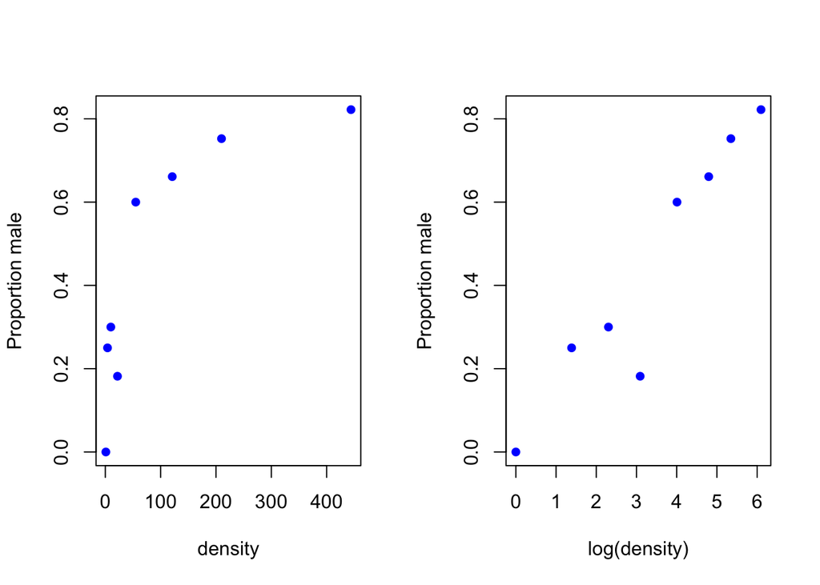

```r
# overview of data
par(mfrow=c(1,2))
# male ratio
p <- males/(males + females)
plot(density, p, ylab = "Proportion male", pch = 16, col = "blue")
# log(density)
plot(log(density), p, ylab = "Proportion male", pch = 16, col = "blue")
```

```r
par(mfrow= c(1, 2))

# glm with binomial errors
y <- cbind(males, females)

model <- glm(y ~ density, family = binomial)

summary(model)
```

```
##
## Call:
## glm(formula = y ~ density, family = binomial)
##
## Deviance Residuals:
##     Min       1Q   Median       3Q      Max
## -3.4619  -1.2760  -0.9911   0.5742   1.8795
##
## Coefficients:
##              Estimate Std. Error z value Pr(>|z|)
## (Intercept) 0.0807368  0.1550376   0.521    0.603
## density     0.0035101  0.0005116   6.862 6.81e-12 ***
## ---
## Signif. codes:  0 '***' 0.001 '**' 0.01 '*' 0.05 '.' 0.1 ' ' 1
##
## (Dispersion parameter for binomial family taken to be 1)
##
##     Null deviance: 71.159  on 7  degrees of freedom
## Residual deviance: 22.091  on 6  degrees of freedom
## AIC: 54.618
##
## Number of Fisher Scoring iterations: 4
```

```r
# there is substantial overdipsersion as deviance is much bigger than the df


# fit log density
model2 <- glm(y ~ log(density), family = binomial)
summary(model2)
```

```
##
## Call:
## glm(formula = y ~ log(density), family = binomial)
##
## Deviance Residuals:
##     Min       1Q   Median       3Q      Max
## -1.9697  -0.3411   0.1499   0.4019   1.0372
##
## Coefficients:
##              Estimate Std. Error z value Pr(>|z|)
## (Intercept)  -2.65927    0.48758  -5.454 4.92e-08 ***
## log(density)  0.69410    0.09056   7.665 1.80e-14 ***
## ---
## Signif. codes:  0 '***' 0.001 '**' 0.01 '*' 0.05 '.' 0.1 ' ' 1
##
## (Dispersion parameter for binomial family taken to be 1)
##
##     Null deviance: 71.1593  on 7  degrees of freedom
## Residual deviance:  5.6739  on 6  degrees of freedom
## AIC: 38.201
##
## Number of Fisher Scoring iterations: 4
```

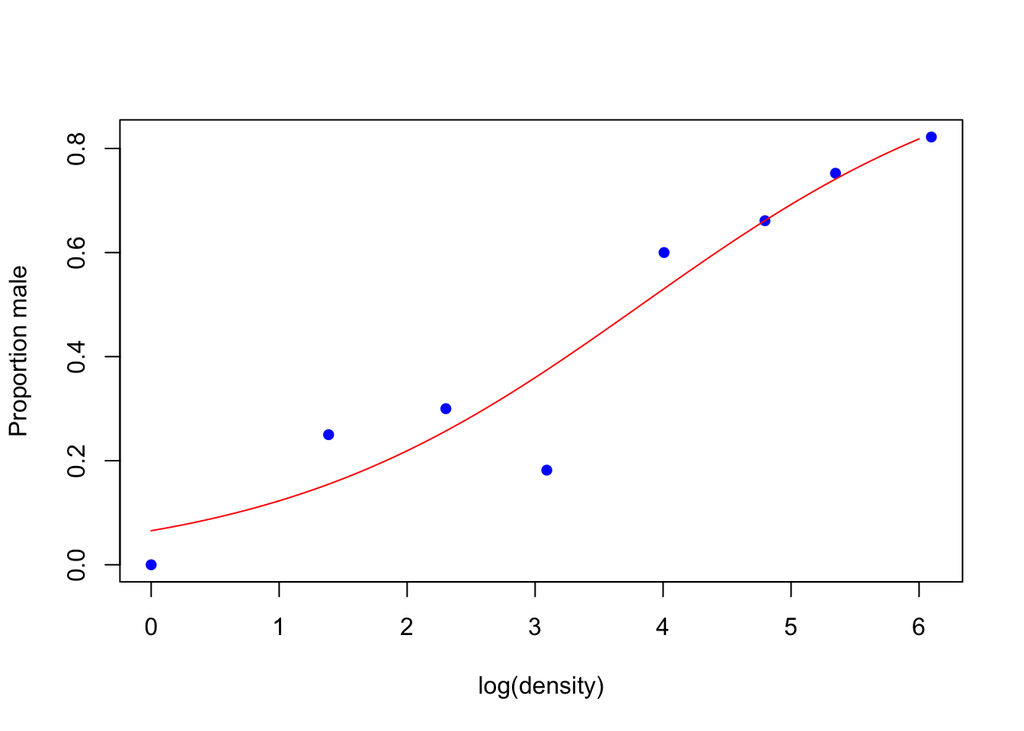

```r
par(mfrow = c(1, 1))

# plot the fitted line
xv <- seq(0, 6, 0.01)
yv <- predict(model2, list(density = exp(xv)), type = "response") # type = response
plot(log(density), p, ylab = "Proportion male", pch = 16, col = "blue")
lines(xv, yv, col = "red")
```

```r
detach(numbers)



# we want to know what kills the 50%(y, dead) ,
# i.e., use y to predict x and work out  a standard error on the x axis
data <- read.table("bioassay.txt", header = TRUE)
attach(data)
head(data)
```

```
##   dose dead batch
## 1    1    2   100
## 2    3   10    90
## 3   10   40    98
## 4   30   96   100
## 5  100   98   100
```

```r
y <- cbind(dead, batch - dead)
model <- glm(y ~ log(dose), family = binomial)

library(MASS)
dose.p(model, p = c(0.5, 0.9, 0.95))
```

```
##               Dose         SE
## p = 0.50: 2.306981 0.07772065
## p = 0.90: 3.425506 0.12362080
## p = 0.95: 3.805885 0.15150043
```

```r
# dose.p(obj, cf = 1:2, p = 0.5)
# dose.p calibrates binomial assays, generalizing the calculation of LD50.
detach(data)


# proportion data with categorical explanatory variabels
germination <- read.table("germination.txt", header = TRUE)
attach(germination)
names(germination)
```

```
## [1] "count"     "sample"    "Orobanche" "extract"
```

```r
y <- cbind(count, sample - count)

levels(Orobanche)
```

```
## [1] "a73" "a75"
```

```r
levels(extract)
```

```
## [1] "bean"     "cucumber"
```

```r
# factorial analysis
model <- glm(y ~ Orobanche * extract, binomial)
summary(model)
```

```
##
## Call:
## glm(formula = y ~ Orobanche * extract, family = binomial)
##
## Deviance Residuals:
##      Min        1Q    Median        3Q       Max
## -2.01617  -1.24398   0.05995   0.84695   2.12123
##
## Coefficients:
##                              Estimate Std. Error z value Pr(>|z|)
## (Intercept)                   -0.4122     0.1842  -2.238   0.0252 *
## Orobanchea75                  -0.1459     0.2232  -0.654   0.5132
## extractcucumber                0.5401     0.2498   2.162   0.0306 *
## Orobanchea75:extractcucumber   0.7781     0.3064   2.539   0.0111 *
## ---
## Signif. codes:  0 '***' 0.001 '**' 0.01 '*' 0.05 '.' 0.1 ' ' 1
##
## (Dispersion parameter for binomial family taken to be 1)
##
##     Null deviance: 98.719  on 20  degrees of freedom
## Residual deviance: 33.278  on 17  degrees of freedom
## AIC: 117.87
##
## Number of Fisher Scoring iterations: 4
```

```r
# approximate dispersion parameter
sum(summary(model)$deviance.resid^2)/summary(model)$df.residual
```

```
## [1] 1.957517
```

```r
# use quasi-binomial
model <- glm(y ~ Orobanche * extract, family = quasibinomial)
summary(model)
```

```
##
## Call:
## glm(formula = y ~ Orobanche * extract, family = quasibinomial)
##
## Deviance Residuals:
##      Min        1Q    Median        3Q       Max
## -2.01617  -1.24398   0.05995   0.84695   2.12123
##
## Coefficients:
##                              Estimate Std. Error t value Pr(>|t|)
## (Intercept)                   -0.4122     0.2513  -1.640   0.1193
## Orobanchea75                  -0.1459     0.3045  -0.479   0.6379
## extractcucumber                0.5401     0.3409   1.584   0.1315
## Orobanchea75:extractcucumber   0.7781     0.4181   1.861   0.0801 .
## ---
## Signif. codes:  0 '***' 0.001 '**' 0.01 '*' 0.05 '.' 0.1 ' ' 1
##
## (Dispersion parameter for quasibinomial family taken to be 1.861832)
##
##     Null deviance: 98.719  on 20  degrees of freedom
## Residual deviance: 33.278  on 17  degrees of freedom
## AIC: NA
##
## Number of Fisher Scoring iterations: 4
```

```r
# update model
model2 <- update(model, ~ . - Orobanche:extract)

anova(model, model2, test = "F")
```

```
## Analysis of Deviance Table
##
## Model 1: y ~ Orobanche * extract
## Model 2: y ~ Orobanche + extract
##   Resid. Df Resid. Dev Df Deviance      F  Pr(>F)
## 1        17     33.278
## 2        18     39.686 -1  -6.4081 3.4418 0.08099 .
## ---
## Signif. codes:  0 '***' 0.001 '**' 0.01 '*' 0.05 '.' 0.1 ' ' 1
```

```r
anova(model2, test = "F")
```

```
## Analysis of Deviance Table
##
## Model: quasibinomial, link: logit
##
## Response: y
##
## Terms added sequentially (first to last)
##
##
##           Df Deviance Resid. Df Resid. Dev       F    Pr(>F)
## NULL                         20     98.719
## Orobanche  1    2.544        19     96.175  1.1954    0.2887
## extract    1   56.489        18     39.686 26.5412 6.692e-05 ***
## ---
## Signif. codes:  0 '***' 0.001 '**' 0.01 '*' 0.05 '.' 0.1 ' ' 1
```

```r
# Orobanche factor seems not significant in model2
model3 <- update(model2, ~ . - Orobanche)
anova(model2, model3, test = "F") # minimal adequate
```

```
## Analysis of Deviance Table
##
## Model 1: y ~ Orobanche + extract
## Model 2: y ~ extract
##   Resid. Df Resid. Dev Df Deviance      F Pr(>F)
## 1        18     39.686
## 2        19     42.751 -1   -3.065 1.4401 0.2457
```

```r
coef(model3)
```

```
##     (Intercept) extractcucumber
##      -0.5121761       1.0574031
```

```r
a <- coef(model3)[1]
b <- coef(model3)[2]

# the p for the first extract type
1/(1+1/(exp(a)))
```

```
## (Intercept)
##   0.3746835
```

```r
# p for the second extract type
1/(1+1/(exp(a + b)))
```

```
## (Intercept)
##   0.6330275
```

```r
# make prediction
tapply(predict(model3, type = "response"), extract, mean)
```

```
##      bean  cucumber
## 0.3746835 0.6330275
```

```r
# the average of raw proportions
as.vector(tapply(count,extract,sum))/as.vector(tapply(sample,extract,sum))
```

```
## [1] 0.3746835 0.6330275
```

```r
# The average of proportions is the total counts over the total samples,
# NOT averaging the raw proportions one by one

detach(germination)
```

## Analysis of covariance with binomial data

Data with both continuous and categorical explanatory variables.

```r
props <- read.table("flowering.txt", header = TRUE)
attach(props)
names(props)
```

```
## [1] "flowered" "number"   "dose"     "variety"
```

```r
# dose continuous, variety categorical
y <- cbind(flowered, number - flowered)
pf <- flowered/number
pfc <- split(pf, variety)
dc <- split(dose, variety)
plot(dose, pf, type = "n", ylab = "Proportion flowered")
points(jitter(dc[[1]]), jitter(pfc[[1]]), pch = 21, col = "blue", bg = "red")
points(jitter(dc[[2]]), jitter(pfc[[2]]), pch = 21, col = "blue", bg = "green")

points(jitter(dc[[3]]), jitter(pfc[[3]]), pch = 21, col = "blue", bg = "yellow")
points(jitter(dc[[4]]), jitter(pfc[[4]]), pch = 21, col = "blue", bg = "green3")
points(jitter(dc[[5]]), jitter(pfc[[5]]), pch = 21, col = "blue", bg = "brown")


# fit maximal model
model1 <- glm(y ~ dose * variety, family = binomial)
summary(model1) # overdispersion
```

```
##
## Call:
## glm(formula = y ~ dose * variety, family = binomial)
##
## Deviance Residuals:
##     Min       1Q   Median       3Q      Max
## -2.6648  -1.1200  -0.3769   0.5735   3.3299
##
## Coefficients:
##               Estimate Std. Error z value Pr(>|z|)
## (Intercept)   -4.59165    1.03215  -4.449 8.64e-06 ***
## dose           0.41262    0.10033   4.113 3.91e-05 ***
## varietyB       3.06197    1.09317   2.801 0.005094 **
## varietyC       1.23248    1.18812   1.037 0.299576
## varietyD       3.17506    1.07516   2.953 0.003146 **
## varietyE      -0.71466    1.54849  -0.462 0.644426
## dose:varietyB -0.34282    0.10239  -3.348 0.000813 ***
## dose:varietyC -0.23039    0.10698  -2.154 0.031274 *
## dose:varietyD -0.30481    0.10257  -2.972 0.002961 **
## dose:varietyE -0.00649    0.13292  -0.049 0.961057
## ---
## Signif. codes:  0 '***' 0.001 '**' 0.01 '*' 0.05 '.' 0.1 ' ' 1
##
## (Dispersion parameter for binomial family taken to be 1)
##
##     Null deviance: 303.350  on 29  degrees of freedom
## Residual deviance:  51.083  on 20  degrees of freedom
## AIC: 123.55
##
## Number of Fisher Scoring iterations: 5
```

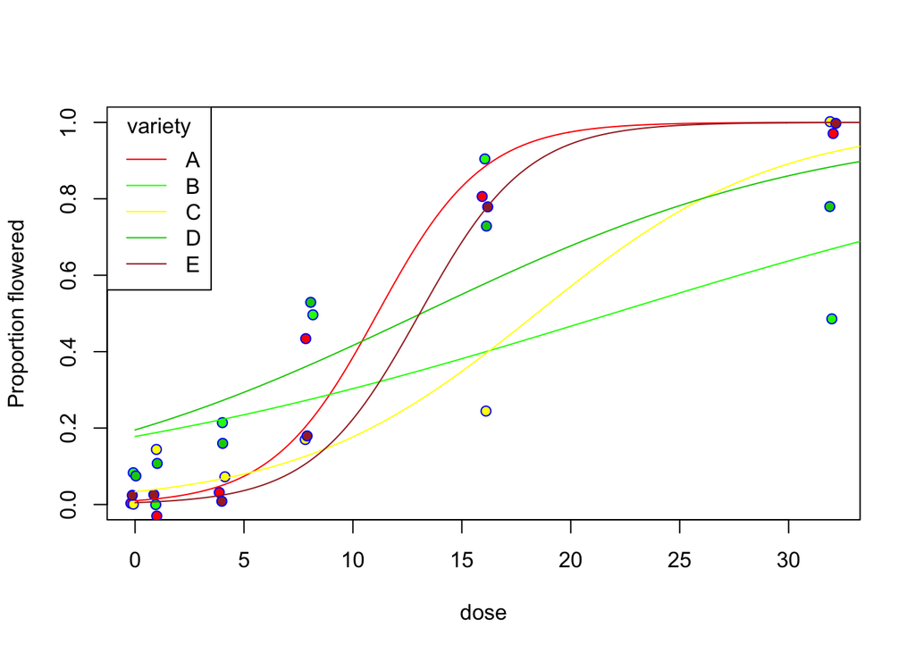

```r
# plot fitted curve
xv <- seq(0, 35, 0.1)
vn <- rep("A", length(xv))
yv <- predict(model1, list(variety = factor(vn), dose = xv), type = "response")
lines(xv, yv, col = "red")
vn <- rep("B", length(xv))
yv <- predict(model1, list(variety = factor(vn), dose = xv), type = "response")
lines(xv, yv, col = "green")
vn <- rep("C", length(xv))
yv <- predict(model1, list(variety = factor(vn), dose = xv), type = "response")
lines(xv, yv, col = "yellow")
vn <- rep("D", length(xv))
yv <- predict(model1, list(variety = factor(vn), dose = xv), type = "response")
lines(xv, yv, col = "green3")

vn <- rep("E", length(xv))
yv <- predict(model1, list(variety = factor(vn), dose = xv), type = "response")
lines(xv, yv, col = "brown")
legend("topleft", legend = c("A", "B", "C", "D", "E"), title = "variety",
            lty = rep(1, 5), col = c("red", "green", "yellow", "green3", "brown"))
```

```r
tapply(pf, list(dose, variety), mean)
```

```
##            A          B          C          D         E
## 0  0.0000000 0.08333333 0.00000000 0.06666667 0.0000000
## 1  0.0000000 0.00000000 0.14285714 0.11111111 0.0000000
## 4  0.0000000 0.20000000 0.06666667 0.15789474 0.0000000
## 8  0.4000000 0.50000000 0.17647059 0.53571429 0.1578947
## 16 0.8181818 0.90000000 0.25000000 0.73076923 0.7500000
## 32 1.0000000 0.50000000 1.00000000 0.77777778 1.0000000
```

```r
detach(props)
```

**Sumamry**: we have proportion data doesn’t necessarily mean that the data will be well described by the logistic model.

## Converting complex contingency tables to proportions

Remove the need for all of the nuisance variables that are involved in complex contingency table modeling.

```r
lizards <- read.table("lizards.txt", header = TRUE)
attach(lizards)
head(lizards)
```

```
##    n   sun height  perch    time  species
## 1 20 Shade   High  Broad Morning opalinus
## 2 13 Shade    Low  Broad Morning opalinus
## 3  8 Shade   High Narrow Morning opalinus
## 4  6 Shade    Low Narrow Morning opalinus
## 5 34   Sun   High  Broad Morning opalinus
## 6 31   Sun    Low  Broad Morning opalinus
```

```r
sorted <- lizards[order(species, sun, height, perch, time), ]
levels(species) # two levels
```

```
## [1] "grahamii" "opalinus"
```

```r
head(sorted)
```

```
##    n   sun height  perch      time  species
## 41 4 Shade   High  Broad Afternoon grahamii
## 33 1 Shade   High  Broad   Mid.day grahamii
## 25 2 Shade   High  Broad   Morning grahamii
## 43 3 Shade   High Narrow Afternoon grahamii
## 35 1 Shade   High Narrow   Mid.day grahamii
## 27 3 Shade   High Narrow   Morning grahamii
```

```r
dim(sorted) # 1-24 one species, 25-48 another species
```

```
## [1] 48  6
```

```r
short <- sorted[1:24, ]

names(short)[1] <- "Ag" # the original "n" column
names(short)
```

```
## [1] "Ag"      "sun"     "height"  "perch"   "time"    "species"
```

```r
head(short)
```

```
##    Ag   sun height  perch      time  species
## 41  4 Shade   High  Broad Afternoon grahamii
## 33  1 Shade   High  Broad   Mid.day grahamii
## 25  2 Shade   High  Broad   Morning grahamii
## 43  3 Shade   High Narrow Afternoon grahamii
## 35  1 Shade   High Narrow   Mid.day grahamii
## 27  3 Shade   High Narrow   Morning grahamii
```

```r
# delete the last column, i.e., the species
short <- short[, -6]
head(short)
```

```
##    Ag   sun height  perch      time
## 41  4 Shade   High  Broad Afternoon
## 33  1 Shade   High  Broad   Mid.day
## 25  2 Shade   High  Broad   Morning
## 43  3 Shade   High Narrow Afternoon
## 35  1 Shade   High Narrow   Mid.day
## 27  3 Shade   High Narrow   Morning
```

```r
new.lizards <- data.frame(sorted$n[25:48], short)

names(new.lizards)[1] <- "Ao"
head(new.lizards)
```

```
##    Ao Ag   sun height  perch      time
## 41  4  4 Shade   High  Broad Afternoon
## 33  8  1 Shade   High  Broad   Mid.day
## 25 20  2 Shade   High  Broad   Morning
## 43  5  3 Shade   High Narrow Afternoon
## 35  4  1 Shade   High Narrow   Mid.day
## 27  8  3 Shade   High Narrow   Morning
```

```r
# create new columns Ao Ag to replace the original "n" column
# deleted the speices column

detach(lizards)
rm(short, sorted)
attach(new.lizards)

names(new.lizards)
```

```
## [1] "Ao"     "Ag"     "sun"    "height" "perch"  "time"
```

```r
y <- cbind(Ao, Ag)

model1 <- glm(y ~ sun * height * perch * time, family = binomial)

model2 <- step(model1)
```

```
## Start:  AIC=102.82
## y ~ sun * height * perch * time
```

```
##                         Df   Deviance    AIC
## - sun:height:perch:time  1 2.1800e-10 100.82
## <none>                     3.5826e-10 102.82
```

```
##
## Step:  AIC=100.82
## y ~ sun + height + perch + time + sun:height + sun:perch + height:perch +
##     sun:time + height:time + perch:time + sun:height:perch +
##     sun:height:time + sun:perch:time + height:perch:time
```

```
##                     Df Deviance     AIC
## - sun:height:time    2   0.4416  97.266
## - sun:perch:time     2   0.8101  97.634
## - height:perch:time  2   3.2217 100.046
## <none>                   0.0000 100.824
## - sun:height:perch   1   2.7088 101.533
##
## Step:  AIC=97.27
## y ~ sun + height + perch + time + sun:height + sun:perch + height:perch +
##     sun:time + height:time + perch:time + sun:height:perch +
##     sun:perch:time + height:perch:time
##
##                     Df Deviance    AIC
## - sun:perch:time     2   1.0713 93.896
## <none>                   0.4416 97.266
## - height:perch:time  2   4.6476 97.472
## - sun:height:perch   1   3.1113 97.936
##
## Step:  AIC=93.9
## y ~ sun + height + perch + time + sun:height + sun:perch + height:perch +
##     sun:time + height:time + perch:time + sun:height:perch +
##     height:perch:time
##
##                     Df Deviance    AIC
## - sun:time           2   3.3403 92.165
## <none>                   1.0713 93.896
## - sun:height:perch   1   3.3016 94.126
## - height:perch:time  2   5.7906 94.615
##
## Step:  AIC=92.16
## y ~ sun + height + perch + time + sun:height + sun:perch + height:perch +
##     height:time + perch:time + sun:height:perch + height:perch:time
##
##                     Df Deviance    AIC
## <none>                   3.3403 92.165
## - sun:height:perch   1   5.8273 92.651
## - height:perch:time  2   8.5418 93.366
```

```r
model3 <- update(model2,~. - height:perch:time)
model4 <- update(model2,~. - sun:height:perch)
anova(model2,model3,test="Chi")
```

```
## Analysis of Deviance Table
##
## Model 1: y ~ sun + height + perch + time + sun:height + sun:perch + height:perch +
##     height:time + perch:time + sun:height:perch + height:perch:time
## Model 2: y ~ sun + height + perch + time + sun:height + sun:perch + height:perch +
##     height:time + perch:time + sun:height:perch
##   Resid. Df Resid. Dev Df Deviance Pr(>Chi)
## 1         7     3.3403
## 2         9     8.5418 -2  -5.2014  0.07422 .
## ---
## Signif. codes:  0 '***' 0.001 '**' 0.01 '*' 0.05 '.' 0.1 ' ' 1
```

```r
anova(model2,model4,test="Chi")
```

```
## Analysis of Deviance Table
##
## Model 1: y ~ sun + height + perch + time + sun:height + sun:perch + height:perch +
##     height:time + perch:time + sun:height:perch + height:perch:time
## Model 2: y ~ sun + height + perch + time + sun:height + sun:perch + height:perch +
##     height:time + perch:time + height:perch:time
##   Resid. Df Resid. Dev Df Deviance Pr(>Chi)
## 1         7     3.3403
## 2         8     5.8273 -1   -2.487   0.1148
```

```r
model5 <- glm(y~(sun+height+perch+time)^2-sun:time,binomial)

model6 <- update(model5,~. - sun:height)
anova(model5,model6,test="Chi")
```

```
## Analysis of Deviance Table
##
## Model 1: y ~ (sun + height + perch + time)^2 - sun:time
## Model 2: y ~ sun + height + perch + time + sun:perch + height:perch +
##     height:time + perch:time
##   Resid. Df Resid. Dev Df Deviance Pr(>Chi)
## 1        10     10.903
## 2        11     13.254 -1  -2.3511   0.1252
```

```r
model7 <- update(model5,~. - sun:perch)
anova(model5,model7,test="Chi")
```

```
## Analysis of Deviance Table
##
## Model 1: y ~ (sun + height + perch + time)^2 - sun:time
## Model 2: y ~ sun + height + perch + time + sun:height + height:perch +
##     height:time + perch:time
##   Resid. Df Resid. Dev Df  Deviance Pr(>Chi)
## 1        10     10.903
## 2        11     10.927 -1 -0.023597   0.8779
```

```r
model8 <- update(model5,~. - height:perch)
anova(model5,model8,test="Chi")
```

```
## Analysis of Deviance Table
##
## Model 1: y ~ (sun + height + perch + time)^2 - sun:time
## Model 2: y ~ sun + height + perch + time + sun:height + sun:perch + height:time +
##     perch:time
##   Resid. Df Resid. Dev Df Deviance Pr(>Chi)
## 1        10     10.903
## 2        11     11.143 -1 -0.24006   0.6242
```

```r
model9 <- update(model5,~. - time:perch)
anova(model5,model9,test="Chi")
```

```
## Analysis of Deviance Table
##
## Model 1: y ~ (sun + height + perch + time)^2 - sun:time
## Model 2: y ~ sun + height + perch + time + sun:height + sun:perch + height:perch +
##     height:time
##   Resid. Df Resid. Dev Df   Deviance Pr(>Chi)
## 1        10     10.903
## 2        12     10.909 -2 -0.0058263   0.9971
```

```r
model10 <- update(model5,~. - time:height)
anova(model5,model10,test="Chi")
```

```
## Analysis of Deviance Table
##
## Model 1: y ~ (sun + height + perch + time)^2 - sun:time
## Model 2: y ~ sun + height + perch + time + sun:height + sun:perch + height:perch +
##     perch:time
##   Resid. Df Resid. Dev Df Deviance Pr(>Chi)
## 1        10     10.903
## 2        12     11.760 -2 -0.85679   0.6516
```

```r
model11 <- glm(y~sun+height+perch+time,binomial)
summary(model11)
```

```
##
## Call:
## glm(formula = y ~ sun + height + perch + time, family = binomial)
##
## Deviance Residuals:
##      Min        1Q    Median        3Q       Max
## -1.66015  -0.37800   0.04488   0.62644   1.48717
##
## Coefficients:
##             Estimate Std. Error z value Pr(>|z|)
## (Intercept)   1.2079     0.3536   3.416 0.000634 ***
## sunSun       -0.8473     0.3224  -2.628 0.008585 **
## heightLow     1.1300     0.2571   4.395 1.11e-05 ***
## perchNarrow  -0.7626     0.2113  -3.610 0.000306 ***
## timeMid.day   0.9639     0.2816   3.423 0.000619 ***
## timeMorning   0.7368     0.2990   2.464 0.013730 *
## ---
## Signif. codes:  0 '***' 0.001 '**' 0.01 '*' 0.05 '.' 0.1 ' ' 1
##
## (Dispersion parameter for binomial family taken to be 1)
##
##     Null deviance: 70.102  on 22  degrees of freedom
## Residual deviance: 14.205  on 17  degrees of freedom
## AIC: 83.029
##
## Number of Fisher Scoring iterations: 4
```

```r
# combine levels
t2 <- time
levels(t2)[c(2,3)] <- "other"
levels(t2)
```

```
## [1] "Afternoon" "other"
```

```r
model12 <- glm(y~sun+height+perch+t2,binomial)
anova(model11,model12,test="Chi")
```

```
## Analysis of Deviance Table
##
## Model 1: y ~ sun + height + perch + time
## Model 2: y ~ sun + height + perch + t2
##   Resid. Df Resid. Dev Df Deviance Pr(>Chi)
## 1        17     14.205
## 2        18     15.023 -1 -0.81863   0.3656
```

```r
summary(model12)
```

```
##
## Call:
## glm(formula = y ~ sun + height + perch + t2, family = binomial)
##
## Deviance Residuals:
##      Min        1Q    Median        3Q       Max
## -1.59707  -0.37407   0.06965   0.64616   1.53004
##
## Coefficients:
##             Estimate Std. Error z value Pr(>|z|)
## (Intercept)   1.1595     0.3484   3.328 0.000874 ***
## sunSun       -0.7872     0.3159  -2.491 0.012722 *
## heightLow     1.1188     0.2566   4.360  1.3e-05 ***
## perchNarrow  -0.7485     0.2104  -3.557 0.000375 ***
## t2other       0.8717     0.2611   3.338 0.000844 ***
## ---
## Signif. codes:  0 '***' 0.001 '**' 0.01 '*' 0.05 '.' 0.1 ' ' 1
##
## (Dispersion parameter for binomial family taken to be 1)
##
##     Null deviance: 70.102  on 22  degrees of freedom
## Residual deviance: 15.023  on 18  degrees of freedom
## AIC: 81.847
##
## Number of Fisher Scoring iterations: 4
```

```r
detach(new.lizards)
rm(y)
```

# Chapter 17 Binary response variables

Steps:

1. Create a single vector containing 0s and 1s as response variables.
2. Use `glm` with `family = binomial`.
3. Consider changing the link function from default logit to complementary log-log.
4. Fit the model in the usual way.
5. Test significance by deletion of terms from the maximal model, and compare the change in deviance with chi-squared.

```r
island <- read.table("isolation.txt", header = TRUE)
attach(island)
names(island)
```

```
## [1] "incidence" "area"      "isolation"
```

```r
# incidence is 1 or 0

# maximal
model1 <- glm(incidence ~ area * isolation, family = binomial)

# w/o interaction
model2 <- glm(incidence ~ area + isolation, family = binomial)

anova(model1, model2, test = "Chi")
```

```
## Analysis of Deviance Table
##
## Model 1: incidence ~ area * isolation
## Model 2: incidence ~ area + isolation
##   Resid. Df Resid. Dev Df Deviance Pr(>Chi)
## 1        46     28.252
## 2        47     28.402 -1 -0.15043   0.6981
```

```r
summary(model2)
```

```
##
## Call:
## glm(formula = incidence ~ area + isolation, family = binomial)
##
## Deviance Residuals:
##     Min       1Q   Median       3Q      Max
## -1.8189  -0.3089   0.0490   0.3635   2.1192
##
## Coefficients:
##             Estimate Std. Error z value Pr(>|z|)
## (Intercept)   6.6417     2.9218   2.273  0.02302 *
## area          0.5807     0.2478   2.344  0.01909 *
## isolation    -1.3719     0.4769  -2.877  0.00401 **
## ---
## Signif. codes:  0 '***' 0.001 '**' 0.01 '*' 0.05 '.' 0.1 ' ' 1
##
## (Dispersion parameter for binomial family taken to be 1)
##
##     Null deviance: 68.029  on 49  degrees of freedom
## Residual deviance: 28.402  on 47  degrees of freedom
## AIC: 34.402
##
## Number of Fisher Scoring iterations: 6
```

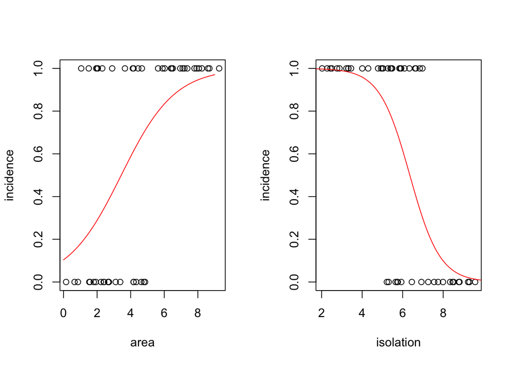

```r
# plot fitted lines against each separately variable
modela <- glm(incidence ~ area, family = binomial)
modeli <- glm(incidence ~ isolation, family = binomial)

par(mfrow=c(1, 2))
xv <- seq(0, 9, 0.01)
yv <- predict(modela, list(area = xv), type = "response")
plot(area, incidence)
lines(xv, yv, col = "red")
xv2 <- seq(0, 10, 0.01)
yv2 <- predict(modeli, list(isolation = xv2), type = "response")
plot(isolation, incidence)
lines(xv2, yv2, col = "red")
```

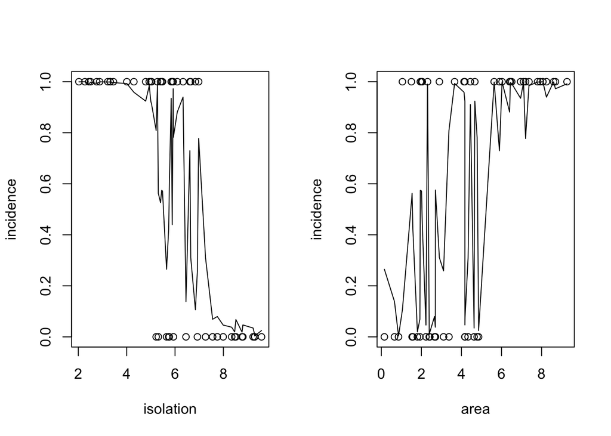

```r
plot(isolation, incidence)
lines(isolation[order(isolation)], predict(model2, type = "response")[order(isolation)])
plot(area, incidence)
lines(area[order(area)], predict(model2, type = "response")[order(area)])
```

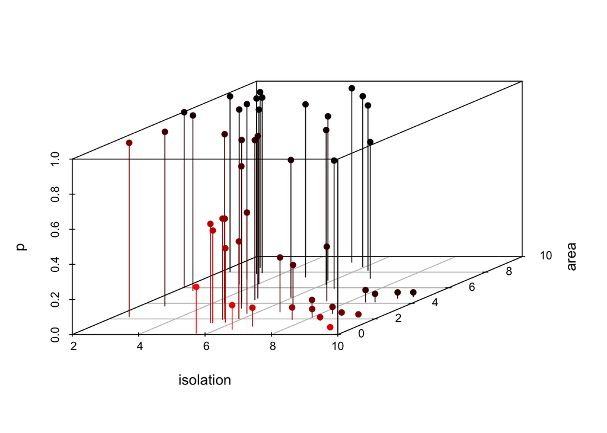

```r
par(mfrow = c(1, 1))




library(scatterplot3d)
s3d <- scatterplot3d(x = isolation, y = area, z = predict(model2, type = "response"),
                     pch = 16, highlight.3d = TRUE, type = "h", zlab = "p")
```

```r
detach(island)
```